# DA 460 Midterm Exam

Marjorie Blanco

July 22, 2018

# Midterm Exam Part 1 – R

## Problem 1

Researchers did investigation on the situation of smoking in Great Britain and got the sample data set smoking.csv (or smoking.txt), read the data set and answer the following questions.

### Question 1

Download smoking.csv (or smoking.txt) and read corresponding data into R.

```r
# read data set
smoking <- read_csv("smoking.csv")
```

### Question 2

- How many observations are there in this data set?

The dimensions of the data frame is 1691, 12. There are 1691 observations and 12 variables in the smoking data set. The variable names are: gender, age, maritalStatus, highestQualification, nationality, ethnicity, grossIncome, region, smoke, amtWeekends, amtWeekdays, type.

```r
# dimensions of the data frame
dim(smoking)
```

```
## [1] 1691   12
```

- How many variables, and what are they?

There are 12 variables in this data set. The variable names are: gender, age, maritalStatus, highestQualification, nationality, ethnicity, grossIncome, region, smoke, amtWeekends, amtWeekdays, type.

- gender: A categorical vector
- age: A numerical vector
- maritalStatus: A categorical vector
- highestQualification: A categorical vector
- nationality: A categorical vector
- ethnicity: A categorical vector
- grossIncome: A categorical vector
- region: A categorical vector
- smoke: A categorical vector
- amtWeekends: A numerical vector (with NA)
- amtWeekdays: A numerical vector (with NA)
- type: A categorical vector

```r
# number of observations (rows)
dim(smoking)[1]
```

```
## [1] 1691
```

```r
# number of variables (columns)
dim(smoking)[2]
```

```
## [1] 12
```

```r
# variable names
 names(smoking)
```

```
##  [1] "gender"               "age"                  "maritalStatus"
##  [4] "highestQualification" "nationality"          "ethnicity"
##  [7] "grossIncome"          "region"               "smoke"
## [10] "amtWeekends"          "amtWeekdays"          "type"
```

```r
# structure
str(smoking)
```

```
## Classes 'tbl_df', 'tbl' and 'data.frame':    1691 obs. of  12 variables:
##  $ gender              : chr  "Male" "Female" "Male" "Female" ...
##  $ age                 : int  38 42 40 40 39 37 53 44 40 41 ...
##  $ maritalStatus       : chr  "Divorced" "Single" "Married" "Married" ...
##  $ highestQualification: chr  "No Qualification" "No Qualification" "Degree" "Degree" ...
##  $ nationality         : chr  "British" "British" "English" "English" ...
##  $ ethnicity           : chr  "White" "White" "White" "White" ...
##  $ grossIncome         : chr  "2,600 to 5,200" "Under 2,600" "28,600 to 36,400" "10,400 to 15,600" ...
##  $ region              : chr  "The North" "The North" "The North" "The North" ...
##  $ smoke               : chr  "No" "Yes" "No" "No" ...
##  $ amtWeekends         : int  NA 12 NA NA NA NA 6 NA 8 15 ...
##  $ amtWeekdays         : int  NA 12 NA NA NA NA 6 NA 8 12 ...
##  $ type                : chr  NA "Packets" NA NA ...
##  - attr(*, "spec")=List of 2
##   ..$ cols   :List of 12
##   .. ..$ gender              : list()
##   .. .. ..- attr(*, "class")= chr  "collector_character" "collector"
##   .. ..$ age                 : list()
##   .. .. ..- attr(*, "class")= chr  "collector_integer" "collector"
##   .. ..$ maritalStatus       : list()
##   .. .. ..- attr(*, "class")= chr  "collector_character" "collector"
##   .. ..$ highestQualification: list()
##   .. .. ..- attr(*, "class")= chr  "collector_character" "collector"
##   .. ..$ nationality         : list()
##   .. .. ..- attr(*, "class")= chr  "collector_character" "collector"
##   .. ..$ ethnicity           : list()
##   .. .. ..- attr(*, "class")= chr  "collector_character" "collector"
##   .. ..$ grossIncome         : list()
##   .. .. ..- attr(*, "class")= chr  "collector_character" "collector"
##   .. ..$ region              : list()
##   .. .. ..- attr(*, "class")= chr  "collector_character" "collector"
##   .. ..$ smoke               : list()
##   .. .. ..- attr(*, "class")= chr  "collector_character" "collector"
##   .. ..$ amtWeekends         : list()
##   .. .. ..- attr(*, "class")= chr  "collector_integer" "collector"
##   .. ..$ amtWeekdays         : list()
##   .. .. ..- attr(*, "class")= chr  "collector_integer" "collector"
##   .. ..$ type                : list()
##   .. .. ..- attr(*, "class")= chr  "collector_character" "collector"
##   ..$ default: list()
##   .. ..- attr(*, "class")= chr  "collector_guess" "collector"
##   ..- attr(*, "class")= chr "col_spec"
```

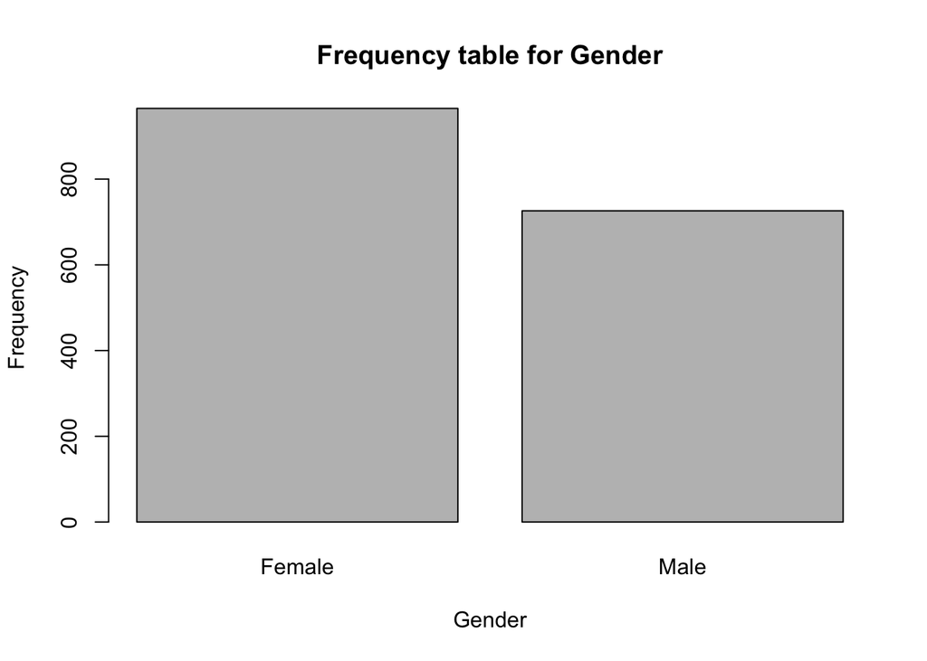

```r
# barplot
barplot(table(smoking$gender), main = "Frequency table for Gender",
       xlab = "Gender", ylab = "Frequency")
```

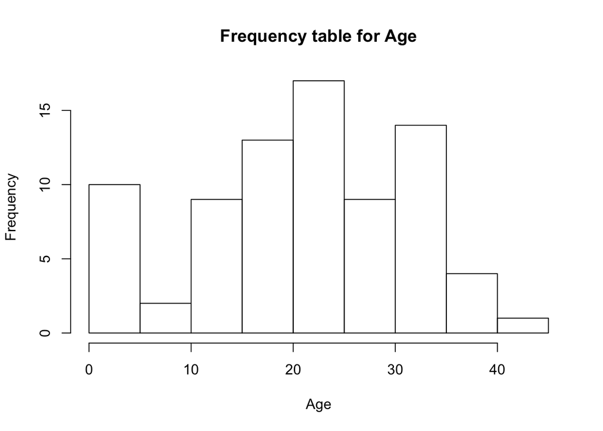

```r
hist(table(smoking$age), main = "Frequency table for Age",
       xlab = "Age", ylab = "Frequency")
```

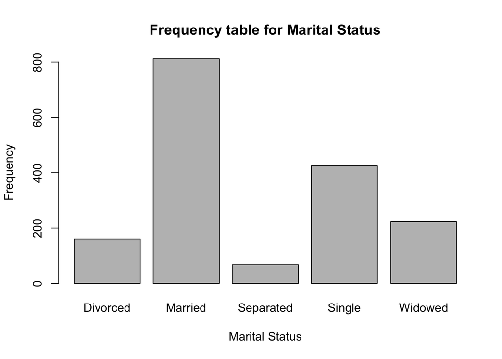

```r
barplot(table(smoking$maritalStatus), main = "Frequency table for Marital Status",
       xlab = "Marital Status", ylab = "Frequency")
```

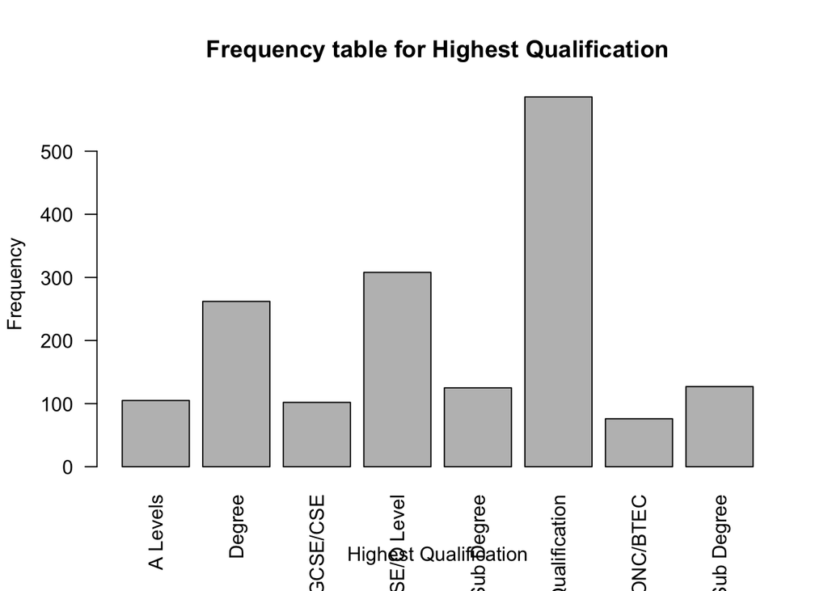

```r
barplot(table(smoking$highestQualification), main = "Frequency table for Highest Qualification",
       xlab = "Highest Qualification", ylab = "Frequency", las=2)
```

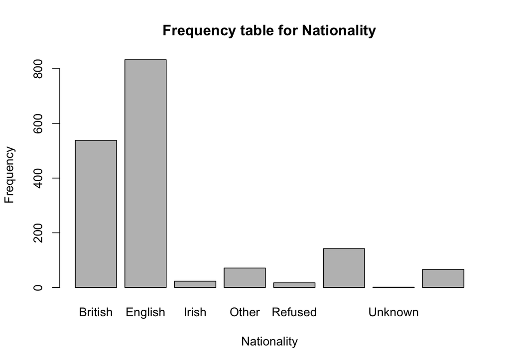

```r
barplot(table(smoking$nationality), main = "Frequency table for Nationality",
       xlab = "Nationality", ylab = "Frequency")
```

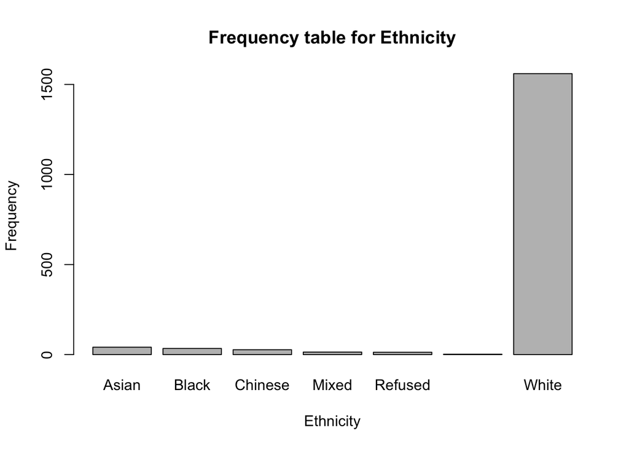

```r
barplot(table(smoking$ethnicity), main = "Frequency table for Ethnicity",
       xlab = "Ethnicity", ylab = "Frequency")
```

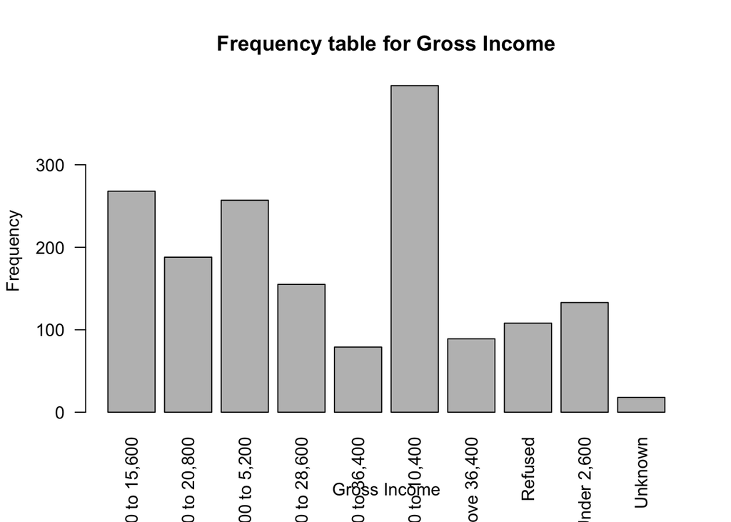

```r
barplot(table(smoking$grossIncome), main = "Frequency table for Gross Income",
       xlab = "Gross Income", ylab = "Frequency", las=2)
```

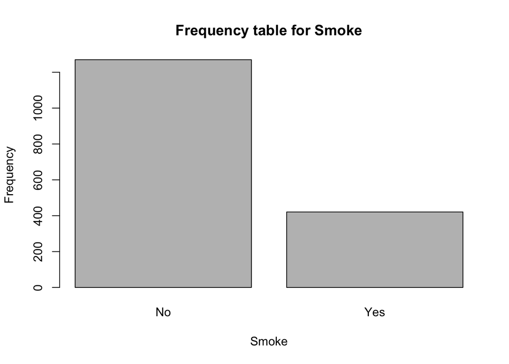

```r
barplot(table(smoking$smoke), main = "Frequency table for Smoke",
       xlab = "Smoke", ylab = "Frequency")
```

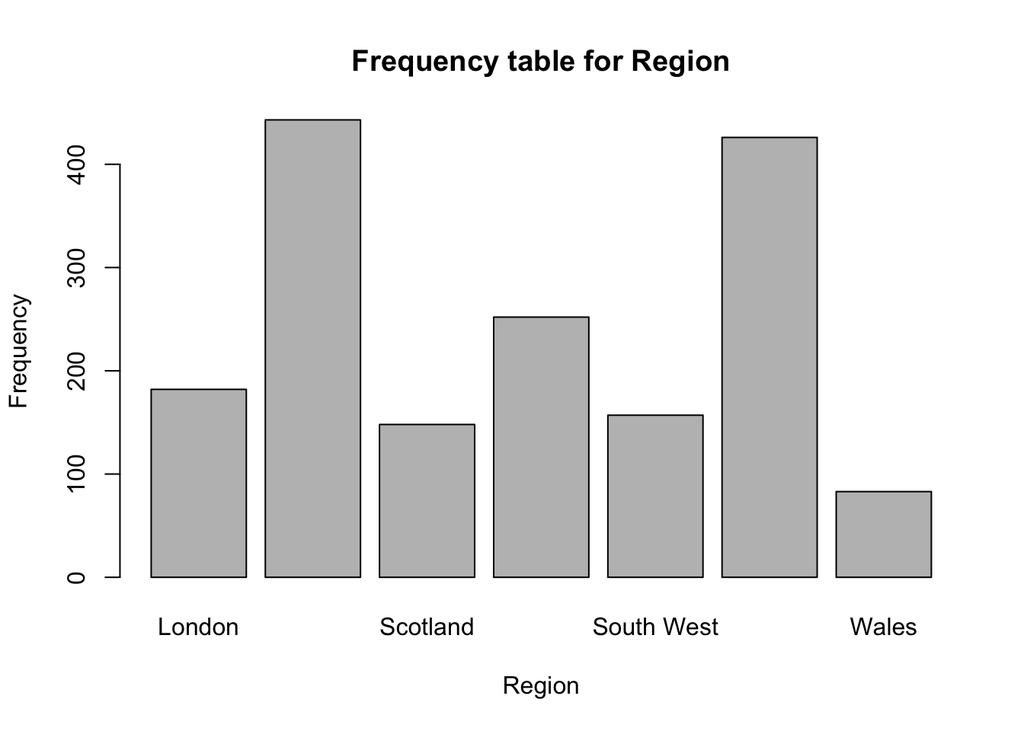

```r
barplot(table(smoking$region), main = "Frequency table for Region",
       xlab = "Region", ylab = "Frequency")
```

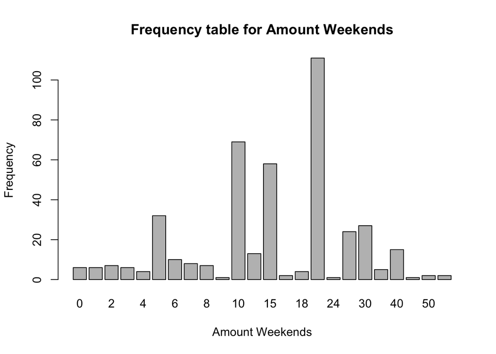

```r
barplot(table(smoking$amtWeekends), main = "Frequency table for Amount Weekends",
       xlab = "Amount Weekends", ylab = "Frequency")
```

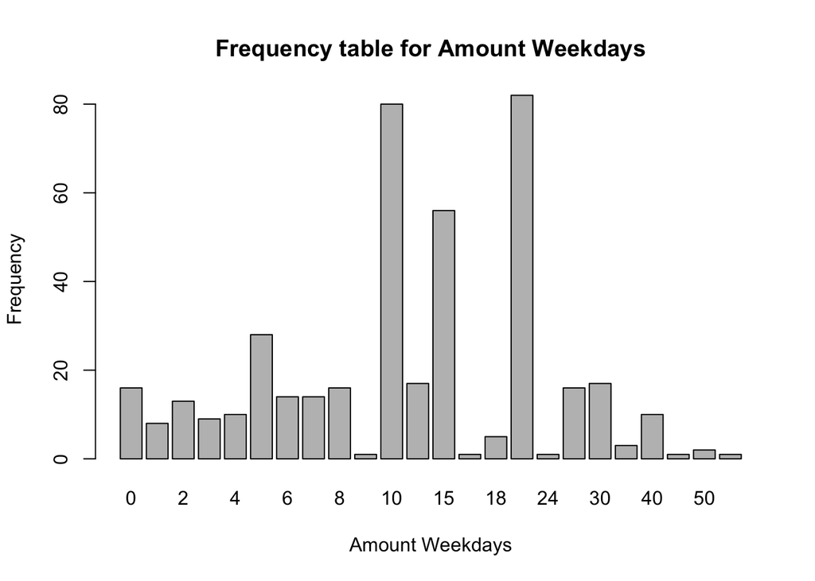

```r
barplot(table(smoking$amtWeekdays), main = "Frequency table for Amount Weekdays",
       xlab = "Amount Weekdays", ylab = "Frequency")
```

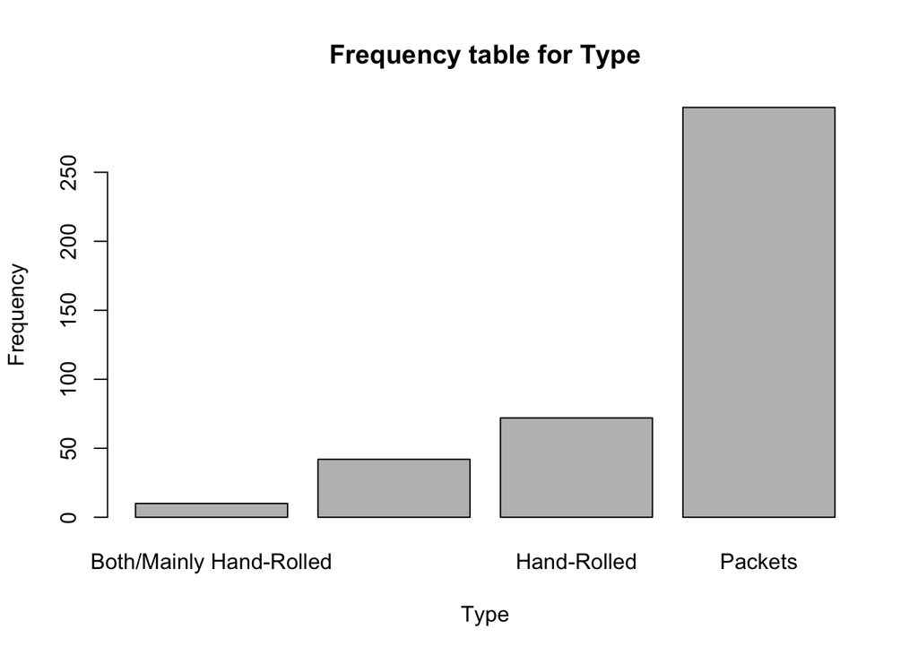

```r
barplot(table(smoking$type), main = "Frequency table for Type",
       xlab = "Type", ylab = "Frequency")
```

- What is the 300th observation of `nationality`?

The 300th observation of nationality is British.

```r
# 300th observation of nationality
smoking[300, "nationality"]
```

```
## # A tibble: 1 x 1
##   nationality
##   <chr>
## 1 British
```

### Question 3

Create a numerical summary for `age` and compute the interquartile range. Compute the relative frequency distribution for `gender`. How many males are in the sample?

The are 726 males in the sample.

```r
summary(smoking$age)
```

```
##    Min. 1st Qu.  Median    Mean 3rd Qu.    Max.
##    16.0    34.0    48.0    49.8    65.5    97.0
```

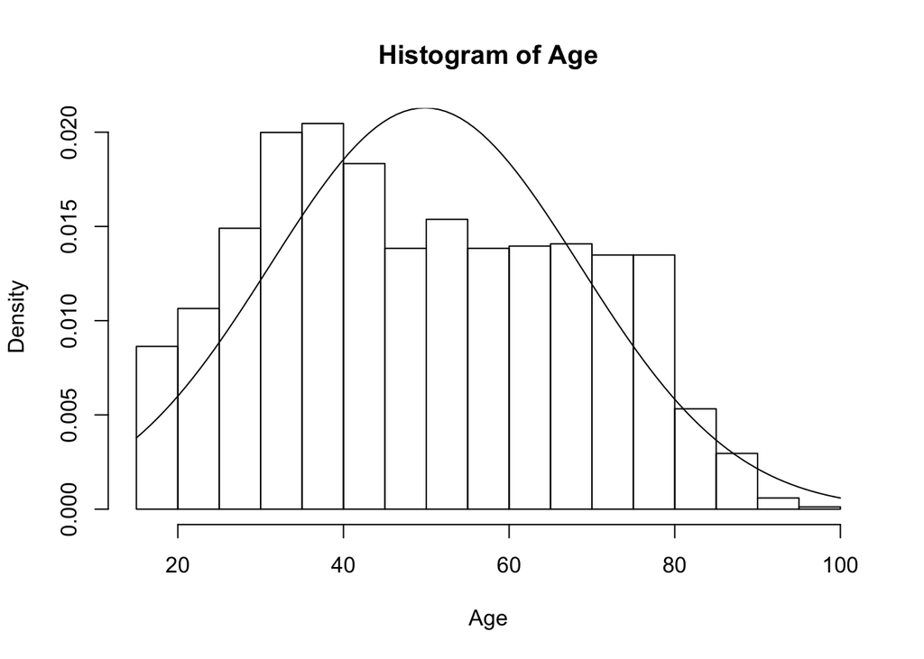

```r
hist(smoking$age, main="Histogram of Age",
     xlab = "Age", prob=TRUE)
curve(dnorm(x, mean=mean(smoking$age), sd=sd(smoking$age)), add=TRUE)
```

```r
table(smoking$gender)
```

```
##
## Female   Male
##    965    726
```

```r
# relative frequency distribution for gender
table(smoking$gender) / length(smoking$gender)
```

```
##
## Female   Male
## 0.5707 0.4293
```

### Question 4

Using numerical summaries and a side-by-side box plot, determine if male smokers are as old as female smokers.

```r
# create subset
female = subset(smoking$age, smoking$gender == "Female")
male = subset(smoking$age, smoking$gender == "Male")

# summary for age for female and male subset
summary(female)
```

```
##    Min. 1st Qu.  Median    Mean 3rd Qu.    Max.
##    16.0    34.0    48.0    50.4    66.0    97.0
```

```r
summary(male)
```

```
##    Min. 1st Qu.  Median    Mean 3rd Qu.    Max.
##    16.0    35.0    48.0    49.2    64.0    91.0
```

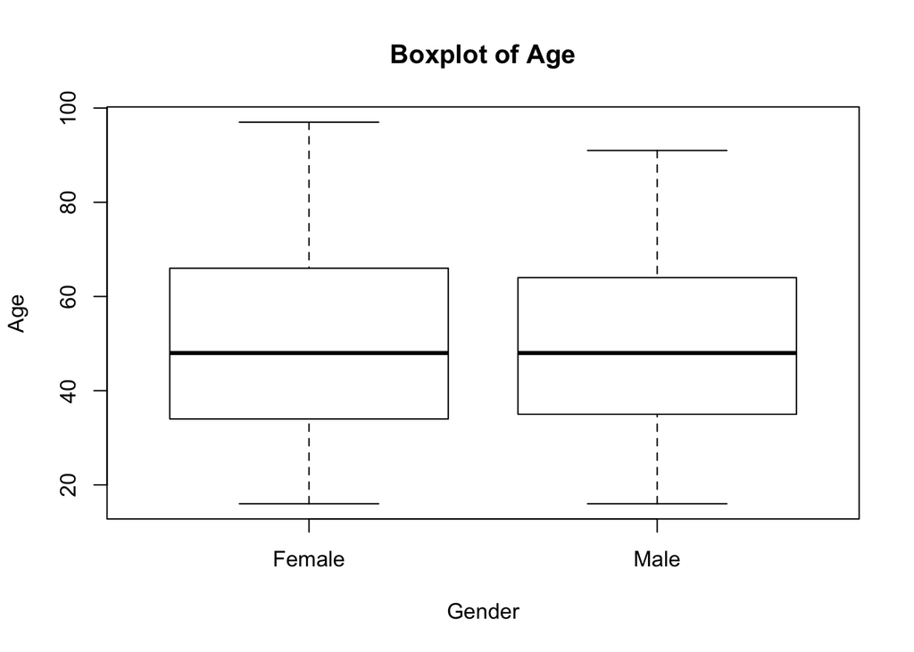

```r
# boxplot of age by gender
boxplot(smoking$age ~ smoking$gender, main="Boxplot of Age",
     ylab = "Age", xlab = "Gender")
```

### Question 5

Create a bar chart or frequency table for `maritalStatus`, what is the proportion for Divorced, Single, Married, and Widowed, respectively? What can you interpret from these numbers?

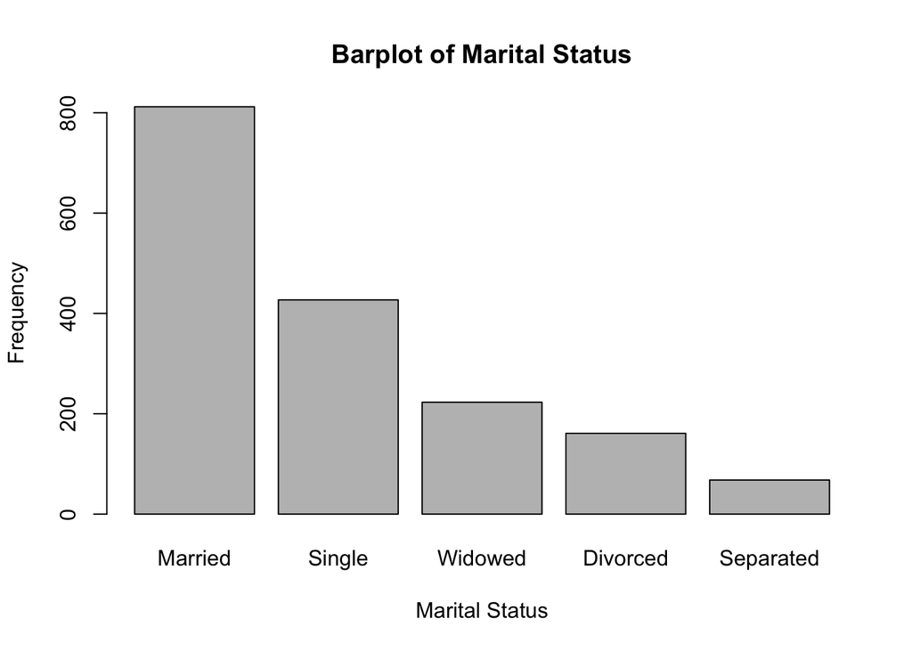

```r
smoking$maritalStatus <- factor(smoking$maritalStatus, levels = c("Married", "Single",  "Widowed", "Divorced", "Separated"))

barplot(table(smoking$maritalStatus), main="Barplot of Marital Status",
     xlab = "Marital Status", ylab = "Frequency")
```

```r
table(smoking$maritalStatus)
```

```
##
##   Married    Single   Widowed  Divorced Separated
##       812       427       223       161        68
```

```r
# relative frequency distribution for maritalStatus
ans <- table(smoking$maritalStatus) / length(smoking$maritalStatus)
ans
```

```
##
##   Married    Single   Widowed  Divorced Separated
##   0.48019   0.25251   0.13187   0.09521   0.04021
```

The proportion for Divorced, Single, Married, and Widowed are 9.521%, 25.251%, 48.019% and 13.187% respectively.

## Problem 2

Apply R simulation to answer the following questions:

### Question 1

Suppose we’re flipping an unfair coin that we know only lands heads 30% of the time. Please simulate this flip 10 times, what is the proportion of heads? If you simulate this flip 100 times, what is the proportion of heads now?

```r
# possible outcome H: heads T: tails
outcomes <- c("H", "T")
# number of simulated coin flips
sampleSize = 10
# flipping an unfair coin lands heads 30% of the time
head = 0.3
```

```r
# run simulation 10 coin flips
sim_coin_flip10 <- sample(outcomes, size = sampleSize, replace = TRUE, prob = c(head, 1 - head))
# view the results of this simulation
table(sim_coin_flip10)
```

```
## sim_coin_flip10
## H T
## 3 7
```

```r
# relative frequency distribution
ans <- table(sim_coin_flip10) / length(sim_coin_flip10)
ans
```

```
## sim_coin_flip10
##   H   T
## 0.3 0.7
```

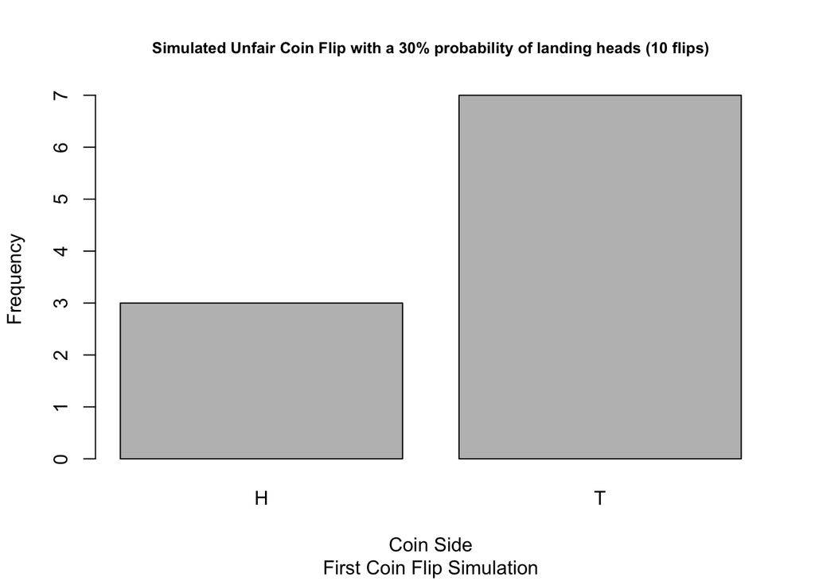

```r
# simulation distribution
barplot(table(sim_coin_flip10), main = "Simulated Unfair Coin Flip with a 30% probability of landing heads (10 flips)",
        sub = "First Coin Flip Simulation", xlab = "Coin Side", ylab = "Frequency", cex.main=0.8)
```

The proportion that land on head is 30%.

```r
# number of simulated coin flips
sampleSize = 100

# run simulation 100 coin flips
sim_coin_flip100 <- sample(outcomes, size = sampleSize, replace = TRUE, prob = c(head, 1 - head))
# view the results of this simulation
table(sim_coin_flip100)
```

```
## sim_coin_flip100
##  H  T
## 31 69
```

```r
# relative frequency distribution
ans <- table(sim_coin_flip100) / length(sim_coin_flip100)
ans
```

```
## sim_coin_flip100
##    H    T
## 0.31 0.69
```

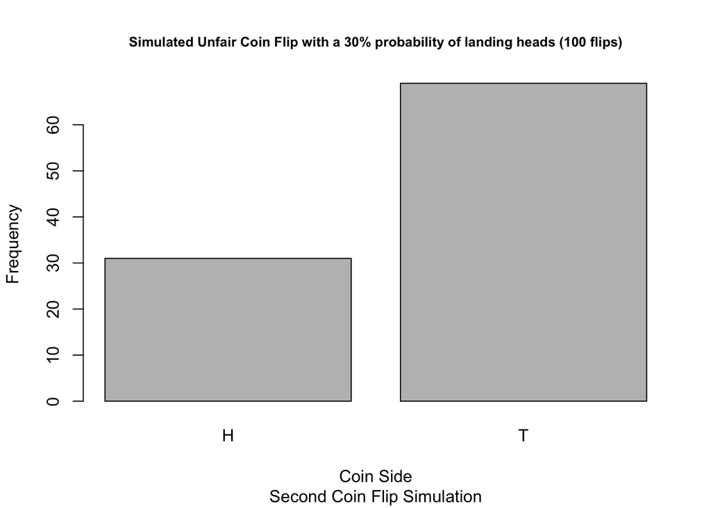

```r
# simulation distribution
barplot(table(sim_coin_flip100), main = "Simulated Unfair Coin Flip with a 30% probability of landing heads (100 flips)",
        sub = "Second Coin Flip Simulation", xlab = "Coin Side", ylab = "Frequency", cex.main=0.8)
```

The proportion that land on head is 31%.

### Question 2

Suppose we’re flipping an unfair dice and the corresponding probability of landing 1, 2, 3, 4, 5, and 6 is 0.05, 0.1, 0.15, 0.2, 0.3, and 0.2, respectively. If you simulate this flip 10 times, what is the proportion of land on side 5? Simulate this flip 100 times, what is the proportion of side 5 now?

```r
# possible outcome 1, 2, 3, 4, 5, and 6
outcomes <- 1:6
# number of simulated dice flips
sampleSize = 10
# corresponding probability of landing 1, 2, 3, 4, 5, and 6
prop_outcome = c(0.05, 0.1, 0.15, 0.2, 0.3, 0.2)
```

```r
# run simulation 10 dice flips
sim_dice_flip10 <- sample(outcomes, size = sampleSize, replace = TRUE, prob = prop_outcome)
# view the results of this simulation
table(sim_dice_flip10)
```

```
## sim_dice_flip10
## 1 3 4 5 6
## 1 2 1 3 3
```

```r
# relative frequency distribution
ans <- table(sim_dice_flip10) / length(sim_dice_flip10)
ans
```

```
## sim_dice_flip10
##   1   3   4   5   6
## 0.1 0.2 0.1 0.3 0.3
```

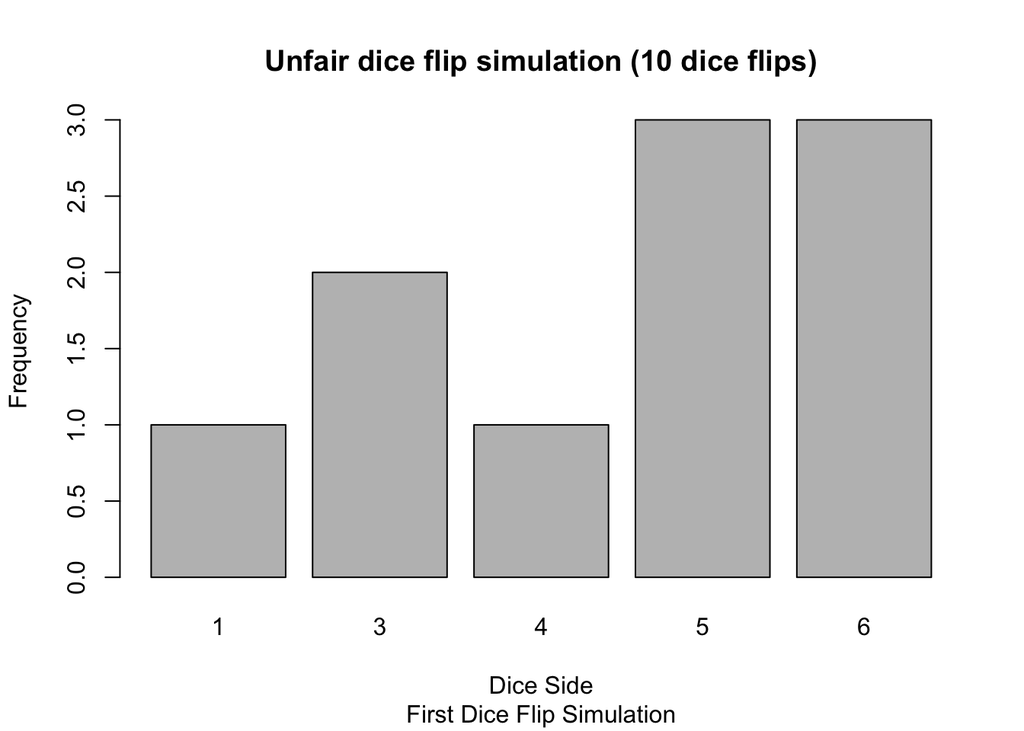

```r
# simulation distribution
barplot(table(sim_dice_flip10), main = "Unfair dice flip simulation (10 dice flips)",
        sub = "First Dice Flip Simulation", xlab = "Dice Side", ylab = "Frequency")
```

The proportion that land on side 5 is 30%.

```r
# number of simulated dice flips
sampleSize = 100
# run simulation 100 dice flips
sim_dice_flip100 <- sample(outcomes, size = sampleSize, replace = TRUE, prob = prop_outcome)

# view the results of this simulation
table(sim_dice_flip100)
```

```
## sim_dice_flip100
##  1  2  3  4  5  6
##  5 12 15 24 28 16
```

```r
# relative frequency distribution
ans <- table(sim_dice_flip100) / length(sim_dice_flip100)
ans
```

```
## sim_dice_flip100
##    1    2    3    4    5    6
## 0.05 0.12 0.15 0.24 0.28 0.16
```

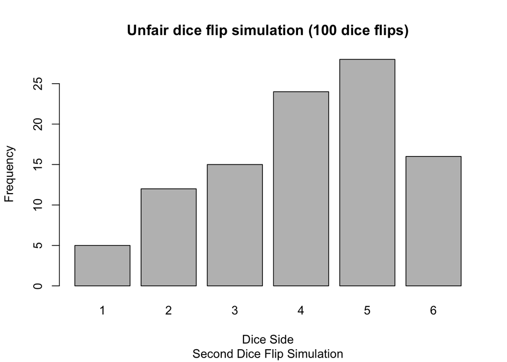

```r
# simulation distribution
barplot(table(sim_dice_flip100), main = "Unfair dice flip simulation (100 dice flips)",
        sub = "Second Dice Flip Simulation", xlab = "Dice Side", ylab = "Frequency")
```

The proportion that land on side 5 is 28%.

### Question 3

Compare the proportions in each questions above, what conclusion can you draw? Does the number of simulations affect the proportions? If so, how? Please explain in details.

The number of simulations did affect the proportions. The proportions has less variability with large sample sizes than with small sample sizes.

```r
# relative frequency distribution for 10 coin flip
table(sim_coin_flip10) / length(sim_coin_flip10)
```

```
## sim_coin_flip10
##   H   T
## 0.3 0.7
```

```r
# relative frequency distribution for 100 coin flip
table(sim_coin_flip100) / length(sim_coin_flip100)
```

```
## sim_coin_flip100
##    H    T
## 0.31 0.69
```

```r
# relative frequency distribution for 10 dice flip
table(sim_dice_flip10) / length(sim_dice_flip10)
```

```
## sim_dice_flip10
##   1   3   4   5   6
## 0.1 0.2 0.1 0.3 0.3
```

```r
# relative frequency distribution for 100 dice flip
table(sim_dice_flip100) / length(sim_dice_flip100)
```

```
## sim_dice_flip100
##    1    2    3    4    5    6
## 0.05 0.12 0.15 0.24 0.28 0.16
```

## Problem 3

Data set countyComplete.csv (or countyComplete.txt) shows the population information from all counties in US, apply this data set to answer the following questions:

### Question 1

Download countyComplete.csv (or countyComplete.txt) and read corresponding data into R.

```r
# read data set
county <- read_csv("countyComplete.csv")
```

### Question 2

Make a histogram of `pop2010`, how can you describe its distribution, bell-shaped or normal? Is it right skewed or left sewed?

```r
summary(county$pop2010)
```

```
##    Min. 1st Qu.  Median    Mean 3rd Qu.    Max.
##      82   11104   25857   98233   66699 9818605
```

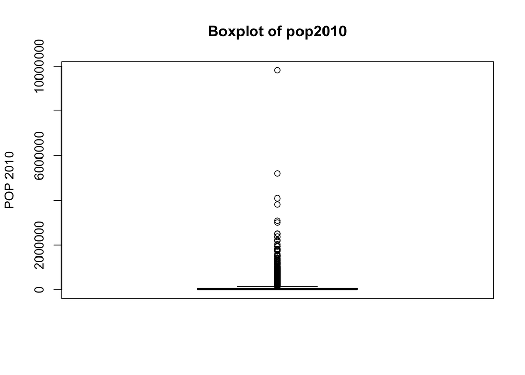

```r
# boxplot of pop2010
boxplot(county$pop2010, main="Boxplot of pop2010",
     ylab = "POP 2010")
```

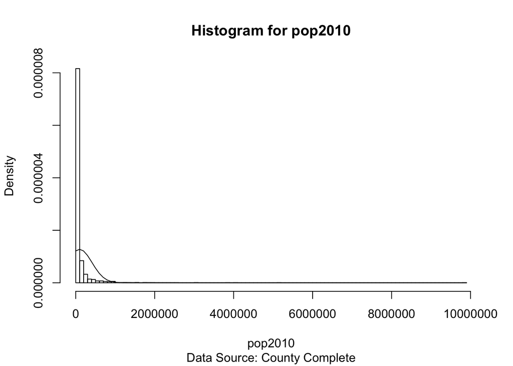

```r
# histogram for pop2010
hist(county$pop2010, breaks = 100, main = "Histogram for pop2010", xlab = "pop2010",
     sub="Data Source: County Complete", prob=TRUE)
curve(dnorm(x, mean=mean(county$pop2010), sd=sd(county$pop2010)), add=TRUE)
```

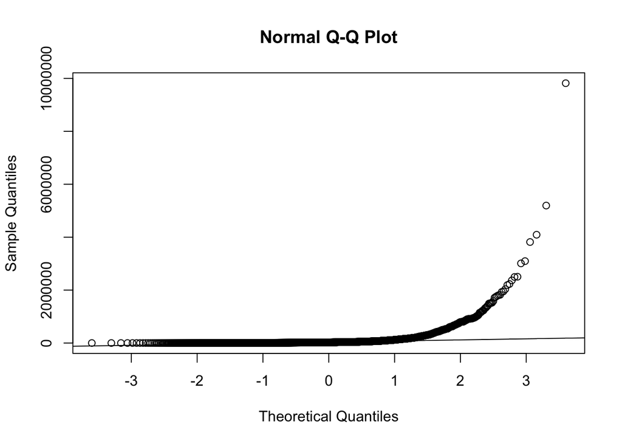

```r
# construct a normal probability plot
qqnorm(county$pop2010)
qqline(county$pop2010)
```

The distribution for `pop2010` is not normally distributed but right skewed. The median (25857) is less than the mean (98232.752).

The data follow does not follow a normal distribution.

- Mean: 98232.752
- Median: 25857
- SD: 312901.202

### Question 3

Create a new subset named Washington which contains only the observations of Washington, and then make a histogram of pop2010, how can you describe its distribution, bell-shaped or normal? Is it right skewed or left sewed? Compare this with question 1.

```r
Washington = subset(county$pop2010, county$state == "Washington")
summary(Washington)
```

```
##    Min. 1st Qu.  Median    Mean 3rd Qu.    Max.
##    2266   20619   60699  172424  146039 1931249
```

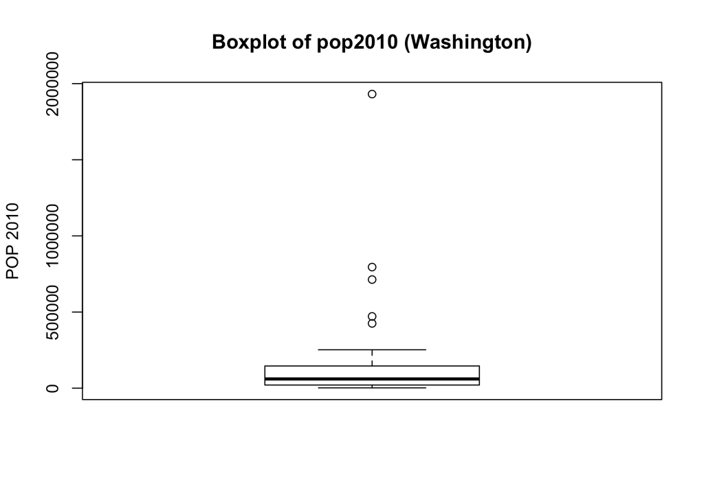

```r
# boxplot of pop2010 for state = Washington
boxplot(Washington, main="Boxplot of pop2010 (Washington)",
     ylab = "POP 2010")
```

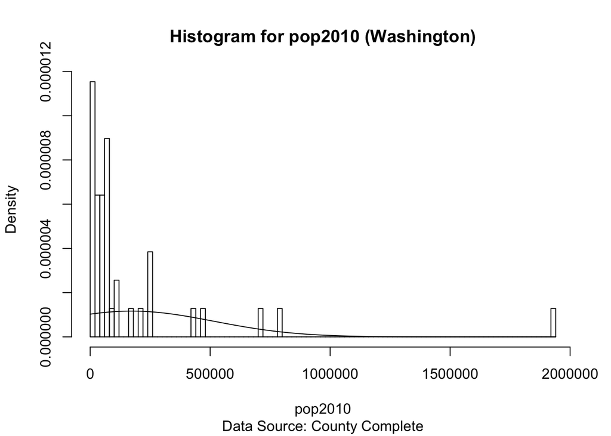

```r
# histogram for pop2010 for state = Washington
hist(Washington, breaks = 100, main = "Histogram for pop2010 (Washington)", xlab = "pop2010",
     sub="Data Source: County Complete", prob=TRUE)
curve(dnorm(x, mean=mean(Washington), sd=sd(Washington)), add=TRUE)
```

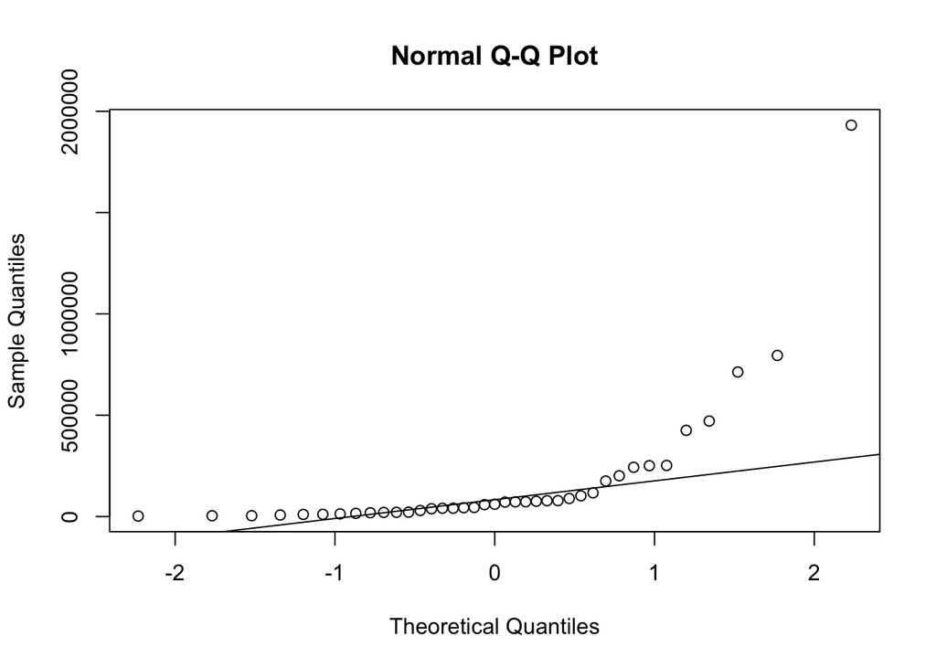

```r
# construct a normal probability plot
qqnorm(Washington)
qqline(Washington)
```

The distribution for `Washington` is not normally distributed but right skewed. The median (60699) is less than the mean (172424) .

The data follow does not follow a normal distribution.

- Mean: 172424.1026
- Median: 60699
- SD: 342451.3523

### Question 4

Based on the subset Washington, make a normal probability plot of pop2010. Do all of the points fall on the line? How does this plot compare to the probability plot of the original data?

Not all of the points fall on the line for both the country and Washington data set. Both probability plot are very similar.

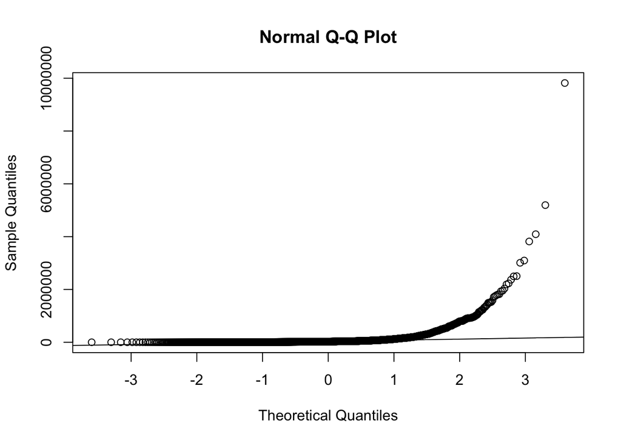

```r
# construct a normal probability plot for data set (county)
qqnorm(county$pop2010)
qqline(county$pop2010)
```

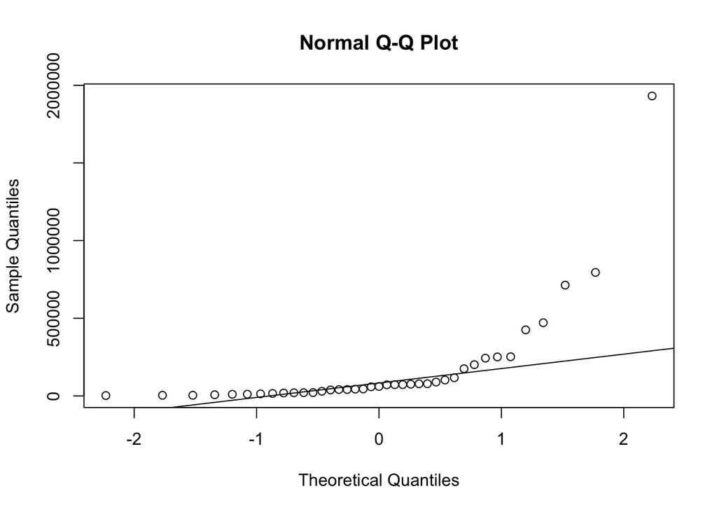

```r
# construct a normal probability plot for data set (Washington)
qqnorm(Washington)
qqline(Washington)
```

### Question 5

Suppose the variable pop2010 has a normal distribution, what is the probability that pop2010 is greater than 102,410? What is the probability that pop2010 is between 190,000 and 1,000,000? Include both the code/command and the output/graph.

```r
# calculate probability by calculating a Z score and consulting a Z table, theoretical
prop1 <- 1 - pnorm(q = 102410, mean = mean(county$pop2010), sd = sd(county$pop2010))
prop1
```

```
## [1] 0.4947
```

```r
# calculate probability by calculating a Z score and consulting a Z table, theoretical
prop2 <- pnorm(q = 1000000, mean = mean(county$pop2010), sd = sd(county$pop2010)) - pnorm(q = 190000, mean = mean(county$pop2010), sd = sd(county$pop2010))
prop2
```

```
## [1] 0.3827
```

The probability that pop2010 is greater than 102,410 is 49.47%. The probability that pop2010 is between 190,000 and 1,000,000 is 38.27%.